# Script 1 - Parasite detection and quantification

Blood parasites and avian health

Marie Buysse, Mathilde Ollagnier, Charly Souc, Marjorie Bruley, Thomas Blanchon, Carole Leray, Marion Vittecoq and Karen D. McCoy

# 0.Librairies

```r
library(readxl) #read_excel function
library(ggplot2)
```

**Important information:**  
For chicks monitored during 2024, blood samples were taken at different times during their growth. Each of these samples was included in the *Babesia* detection analyses using blood smears and qPCR techniques. There are therefore several lines of data for the same individual. The number of data items in the following datasets should not be taken as an indicator of prevalence. Prevalence data is analysed in `Script 2`.

# 1.Sensitivity of qPCR and blood smears techniques

## 1.1.2-way contingency table

```r
data <- read_excel("Data_Parasite detection and quantification.xlsx")
```

With:  
-Site: sampling colony (Carteau/Frioul)  
-Sample: ID of individual bird (the addition of the suffix type ’_1’ or ’_2’ indicates the number of the blood sample for the same individual)  
-Year: sampling year (2022/2023/2024)  
-Age: age of bird (Chick/Adult)  
-Smear: infection status based on blood smears technique (uninfected/infected)  
-qPCR: infection status based on qPCR technique (uninfected/infected)

We produce a 2-way contingency table:

```r
tabCont=table(data$qPCR,data$Smear)
tabCont_marg <- addmargins(tabCont)
colnames(tabCont_marg) <- c("Smear:INF", "Smear:UNINF","Sum")
rownames(tabCont_marg) <- c("qPCR:INF", "qPCR:UNINF","Sum")
print(tabCont_marg)
```

```
##
##              Smear:INF Smear:UNINF Sum
##   qPCR:INF          47          35  82
##   qPCR:UNINF        16         202 218
##   Sum               63         237 300
```

## 1.2.McNemar’s test

```r
mcnemar.test(tabCont)
```

```
##
##  McNemar's Chi-squared test with continuity correction
##
## data:  tabCont
## McNemar's chi-squared = 6.3529, df = 1, p-value = 0.01172
```

**p-value = 0.01172**  
**We therefore consider that the proportions are significantly different. There were more detections with the qPCR technique than with the blood smears, and in particular N(qPCRINF; smearUNINF) was higher than N(qPCRUNINF; smearINF) (35 vs 16).**

# 2.Infection intensity estimated from each method

```r
data_corr <- read_excel("Data_Parasite detection and quantification_correlation.xlsx")
data_corr$Ratio_qPCR <- as.numeric(data_corr$Ratio_qPCR)
data_corr$Smears_number <- as.numeric(data_corr$Smears_number)
```

With:  
-Site: sampling colony (Carteau/Frioul)  
-Sample: ID of individual bird  
-Year: sampling year (2022/2023/2024)  
-Age: age of bird (Chick/Adult)  
-Smear: infection status based on blood smears technique (uninfected/infected)  
-qPCR: infection status based on qPCR technique (uninfected/infected)  
-Ratio_qPCR: quantification of *Babesia* based on qPCR technique (ratio *Larus*/*Babesia* copies of genes)  
-Smears_number: quantification of *Babesia* based on blood smears technique (number of *Babesia*)

**Important information:**  
This dataset includes only the chicks monitored during 2024 and the adults from the same year. For these samples, the number of *Babesia* was counted for each blood smear, unlike in previous years.

Visualisation:

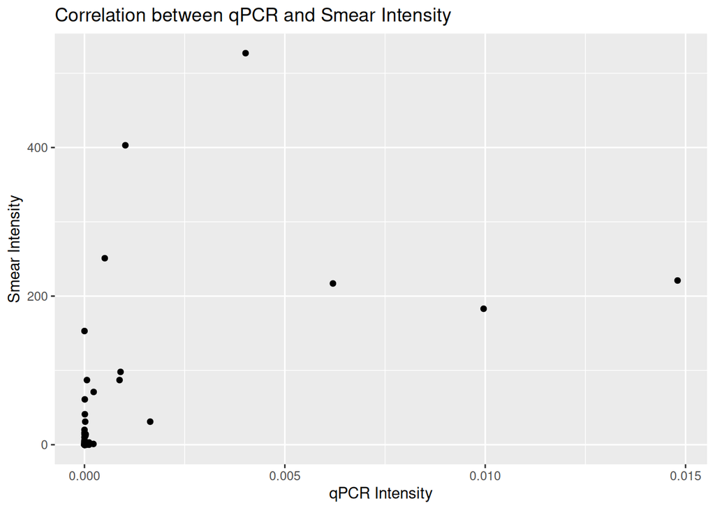

```r
ggplot(data_corr, aes(x = Ratio_qPCR, y = Smears_number)) +
  geom_point() +
  labs(title = "Correlation between qPCR and Smear Intensity",
       x = "qPCR Intensity",
       y = "Smear Intensity")
```

Normality of data distribution:

```r
shapiro.test(data_corr$Ratio_qPCR)
```

```
##
##  Shapiro-Wilk normality test
##
## data:  data_corr$Ratio_qPCR
## W = 0.17391, p-value < 2.2e-16
```

```r
shapiro.test(data_corr$Smears_number)
```

```
##
##  Shapiro-Wilk normality test
##
## data:  data_corr$Smears_number
## W = 0.28925, p-value < 2.2e-16
```

Both `data_corr$Ratio_qPCR` and `data_corr$Smears_number` distribution violate normality.

We used the Spearman’s Rank Correlation non-parametric test:

```r
cor.test(data_corr$Ratio_qPCR, data_corr$Smears_number, method = "spearman")
```

```
##
##  Spearman's rank correlation rho
##
## data:  data_corr$Ratio_qPCR and data_corr$Smears_number
## S = 203635, p-value = 1.693e-15
## alternative hypothesis: true rho is not equal to 0
## sample estimates:
##       rho
## 0.5992059
```

**p-value = 1.693e-15 & rho = 0.5992059**  
**There is a significant moderate positive correlation between `data_corr$Ratio_qPCR` and `data_corr$Smears_number`.**